# Risk Factor Analysis

## Outcome Variable

**Outcome Variable:** haz

## Predictor Variables

**Intervention Variable:** impsan

**Adjustment Set:**

- arm
- sex
- W_mage
- meducyrs
- feducyrs
- hhwealth_quart
- hfoodsec
- W_mhtcm
- W_mwtkg
- W_mbmi
- W_nrooms
- W_nchldlt5
- W_parity
- impfloor
- safeh20
- delta_W_mage
- delta_meducyrs
- delta_feducyrs
- delta_hhwealth_quart
- delta_hfoodsec
- delta_W_mhtcm
- delta_W_mwtkg
- delta_W_mbmi
- delta_W_nrooms
- delta_W_nchldlt5
- delta_W_parity
- delta_impfloor
- delta_safeh20

## Stratifying Variables

The analysis was stratified on these variable(s):

- agecat
- studyid
- country

## Data Summary

| agecat | studyid | country | impsan | n_cell | n | outcome_variable |
| --- | --- | --- | --- | --- | --- | --- |
| Birth | COHORTS | GUATEMALA | 1 | 45 | 491 | haz |
| Birth | COHORTS | GUATEMALA | 0 | 446 | 491 | haz |
| Birth | COHORTS | INDIA | 1 | 1767 | 4776 | haz |
| Birth | COHORTS | INDIA | 0 | 3009 | 4776 | haz |
| Birth | COHORTS | PHILIPPINES | 1 | 178 | 1191 | haz |
| Birth | COHORTS | PHILIPPINES | 0 | 1013 | 1191 | haz |
| Birth | CONTENT | PERU | 1 | 1 | 2 | haz |
| Birth | CONTENT | PERU | 0 | 1 | 2 | haz |
| Birth | JiVitA-3 | BANGLADESH | 1 | 15220 | 22431 | haz |
| Birth | JiVitA-3 | BANGLADESH | 0 | 7211 | 22431 | haz |
| Birth | JiVitA-4 | BANGLADESH | 1 | 2181 | 2820 | haz |
| Birth | JiVitA-4 | BANGLADESH | 0 | 639 | 2820 | haz |
| Birth | MAL-ED | BANGLADESH | 1 | 179 | 213 | haz |
| Birth | MAL-ED | BANGLADESH | 0 | 34 | 213 | haz |
| Birth | MAL-ED | BRAZIL | 1 | 59 | 60 | haz |
| Birth | MAL-ED | BRAZIL | 0 | 1 | 60 | haz |
| Birth | MAL-ED | INDIA | 1 | 15 | 40 | haz |
| Birth | MAL-ED | INDIA | 0 | 25 | 40 | haz |
| Birth | MAL-ED | NEPAL | 1 | 25 | 26 | haz |
| Birth | MAL-ED | NEPAL | 0 | 1 | 26 | haz |
| Birth | MAL-ED | PERU | 1 | 52 | 208 | haz |
| Birth | MAL-ED | PERU | 0 | 156 | 208 | haz |
| Birth | MAL-ED | SOUTH AFRICA | 1 | 0 | 95 | haz |
| Birth | MAL-ED | SOUTH AFRICA | 0 | 95 | 95 | haz |
| Birth | MAL-ED | TANZANIA, UNITED REPUBLIC OF | 1 | 0 | 118 | haz |
| Birth | MAL-ED | TANZANIA, UNITED REPUBLIC OF | 0 | 118 | 118 | haz |
| Birth | NIH-Birth | BANGLADESH | 1 | 231 | 608 | haz |
| Birth | NIH-Birth | BANGLADESH | 0 | 377 | 608 | haz |
| Birth | NIH-Crypto | BANGLADESH | 1 | 632 | 721 | haz |
| Birth | NIH-Crypto | BANGLADESH | 0 | 89 | 721 | haz |

[output cut: 70 more lines]

The following strata were considered:

- agecat: 24 months, studyid: COHORTS, country: GUATEMALA
- agecat: 24 months, studyid: COHORTS, country: INDIA
- agecat: 24 months, studyid: COHORTS, country: PHILIPPINES
- agecat: 24 months, studyid: CONTENT, country: PERU
- agecat: 24 months, studyid: JiVitA-3, country: BANGLADESH
- agecat: 24 months, studyid: JiVitA-4, country: BANGLADESH
- agecat: 24 months, studyid: LCNI-5, country: MALAWI
- agecat: 24 months, studyid: MAL-ED, country: BANGLADESH
- agecat: 24 months, studyid: MAL-ED, country: BRAZIL
- agecat: 24 months, studyid: MAL-ED, country: INDIA
- agecat: 24 months, studyid: MAL-ED, country: NEPAL
- agecat: 24 months, studyid: MAL-ED, country: PERU
- agecat: 24 months, studyid: MAL-ED, country: SOUTH AFRICA
- agecat: 24 months, studyid: MAL-ED, country: TANZANIA, UNITED REPUBLIC OF
- agecat: 24 months, studyid: NIH-Birth, country: BANGLADESH
- agecat: 24 months, studyid: NIH-Crypto, country: BANGLADESH
- agecat: 24 months, studyid: PROVIDE, country: BANGLADESH
- agecat: 6 months, studyid: COHORTS, country: GUATEMALA
- agecat: 6 months, studyid: COHORTS, country: INDIA
- agecat: 6 months, studyid: COHORTS, country: PHILIPPINES
- agecat: 6 months, studyid: CONTENT, country: PERU
- agecat: 6 months, studyid: JiVitA-3, country: BANGLADESH
- agecat: 6 months, studyid: JiVitA-4, country: BANGLADESH
- agecat: 6 months, studyid: LCNI-5, country: MALAWI
- agecat: 6 months, studyid: MAL-ED, country: BANGLADESH
- agecat: 6 months, studyid: MAL-ED, country: BRAZIL
- agecat: 6 months, studyid: MAL-ED, country: INDIA
- agecat: 6 months, studyid: MAL-ED, country: NEPAL
- agecat: 6 months, studyid: MAL-ED, country: PERU
- agecat: 6 months, studyid: MAL-ED, country: SOUTH AFRICA
- agecat: 6 months, studyid: MAL-ED, country: TANZANIA, UNITED REPUBLIC OF
- agecat: 6 months, studyid: NIH-Birth, country: BANGLADESH
- agecat: 6 months, studyid: NIH-Crypto, country: BANGLADESH
- agecat: 6 months, studyid: PROVIDE, country: BANGLADESH
- agecat: Birth, studyid: COHORTS, country: GUATEMALA
- agecat: Birth, studyid: COHORTS, country: INDIA
- agecat: Birth, studyid: COHORTS, country: PHILIPPINES
- agecat: Birth, studyid: CONTENT, country: PERU
- agecat: Birth, studyid: JiVitA-3, country: BANGLADESH
- agecat: Birth, studyid: JiVitA-4, country: BANGLADESH
- agecat: Birth, studyid: MAL-ED, country: BANGLADESH
- agecat: Birth, studyid: MAL-ED, country: BRAZIL
- agecat: Birth, studyid: MAL-ED, country: INDIA
- agecat: Birth, studyid: MAL-ED, country: NEPAL
- agecat: Birth, studyid: MAL-ED, country: PERU
- agecat: Birth, studyid: MAL-ED, country: SOUTH AFRICA
- agecat: Birth, studyid: MAL-ED, country: TANZANIA, UNITED REPUBLIC OF
- agecat: Birth, studyid: NIH-Birth, country: BANGLADESH
- agecat: Birth, studyid: NIH-Crypto, country: BANGLADESH
- agecat: Birth, studyid: PROVIDE, country: BANGLADESH

### Dropped Strata

Some strata were dropped due to rare outcomes:

- agecat: Birth, studyid: CONTENT, country: PERU
- agecat: Birth, studyid: MAL-ED, country: BRAZIL
- agecat: Birth, studyid: MAL-ED, country: NEPAL
- agecat: Birth, studyid: MAL-ED, country: SOUTH AFRICA
- agecat: Birth, studyid: MAL-ED, country: TANZANIA, UNITED REPUBLIC OF
- agecat: Birth, studyid: PROVIDE, country: BANGLADESH
- agecat: 6 months, studyid: LCNI-5, country: MALAWI
- agecat: 6 months, studyid: MAL-ED, country: BRAZIL
- agecat: 6 months, studyid: MAL-ED, country: NEPAL
- agecat: 6 months, studyid: MAL-ED, country: SOUTH AFRICA
- agecat: 6 months, studyid: MAL-ED, country: TANZANIA, UNITED REPUBLIC OF
- agecat: 6 months, studyid: PROVIDE, country: BANGLADESH
- agecat: 24 months, studyid: LCNI-5, country: MALAWI
- agecat: 24 months, studyid: MAL-ED, country: BRAZIL
- agecat: 24 months, studyid: MAL-ED, country: NEPAL
- agecat: 24 months, studyid: MAL-ED, country: SOUTH AFRICA
- agecat: 24 months, studyid: MAL-ED, country: TANZANIA, UNITED REPUBLIC OF
- agecat: 24 months, studyid: PROVIDE, country: BANGLADESH

## Methods Detail

We’re interested in the causal parameters $E[Y_a]$ for all values of $a \in \mathcal{A}$. These parameters represent the mean outcome if, possibly contrary to fact, we intervened to set all units to have $A=a$. Under the randomization and positivity assumptions, these are identified by the statistical parameters $\psi_a=E_W[E_{Y|A,W}(Y|A=a,W)]$. In addition, we’re interested in the mean of $Y$, $E[Y]$ under no intervention (the observed mean). We will estimate these parameters by using SuperLearner to fit the relevant likelihood factors – $E_{Y|A,W}(Y|A=a,W)$ and $p(A=a|W)$, and then updating our likelihood fit using a joint TMLE.

For unadjusted analyses ($W=\{\}$), initial likelihoods were estimated using Lrnr_glm to estimate the simple $E(Y|A)$ and Lrnr_mean to estimate $p(A)$. For adjusted analyses, a small library containing Lrnr_glmnet, Lrnr_xgboost, and Lrnr_mean was used.

Having estimated these parameters, we will then use the delta method to estimate relative risks and attributable risks relative to a prespecified baseline level of $A$.

# Results Detail

## Results Plots

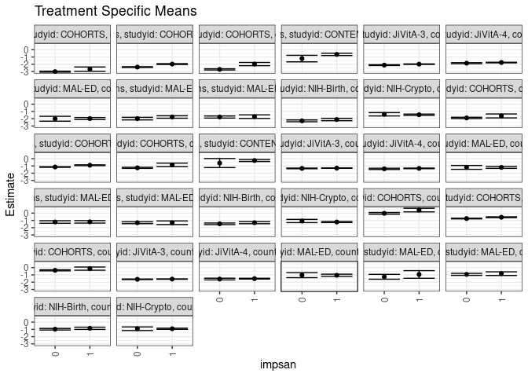

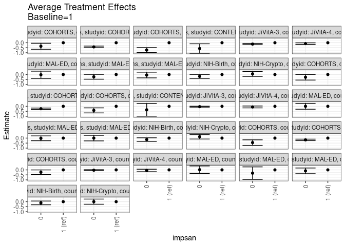

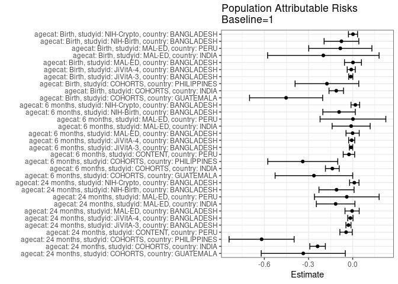

## Results Table

### Parameter: TSM

| agecat | studyid | country | intervention_level | baseline_level | estimate | ci_lower | ci_upper |
| --- | --- | --- | --- | --- | --- | --- | --- |
| Birth | COHORTS | GUATEMALA | 1 | NA | 0.4246927 | 0.1736314 | 0.6757540 |
| Birth | COHORTS | GUATEMALA | 0 | NA | -0.0247529 | -0.1398607 | 0.0903549 |
| Birth | COHORTS | INDIA | 1 | NA | -0.5660231 | -0.6252822 | -0.5067640 |
| Birth | COHORTS | INDIA | 0 | NA | -0.7442746 | -0.7872968 | -0.7012525 |
| Birth | COHORTS | PHILIPPINES | 1 | NA | -0.1386462 | -0.3584132 | 0.0811207 |
| Birth | COHORTS | PHILIPPINES | 0 | NA | -0.3727810 | -0.4427508 | -0.3028112 |
| Birth | JiVitA-3 | BANGLADESH | 1 | NA | -1.5766139 | -1.5999759 | -1.5532519 |
| Birth | JiVitA-3 | BANGLADESH | 0 | NA | -1.6058790 | -1.6469435 | -1.5648145 |
| Birth | JiVitA-4 | BANGLADESH | 1 | NA | -1.5137140 | -1.5702690 | -1.4571591 |
| Birth | JiVitA-4 | BANGLADESH | 0 | NA | -1.5724761 | -1.6897730 | -1.4551792 |
| Birth | MAL-ED | BANGLADESH | 1 | NA | -1.0548761 | -1.2045449 | -0.9052074 |
| Birth | MAL-ED | BANGLADESH | 0 | NA | -1.0361055 | -1.3790315 | -0.6931796 |
| Birth | MAL-ED | INDIA | 1 | NA | -0.9381818 | -1.4638099 | -0.4125537 |
| Birth | MAL-ED | INDIA | 0 | NA | -1.2622665 | -1.5975605 | -0.9269726 |
| Birth | MAL-ED | PERU | 1 | NA | -0.8291202 | -1.0795178 | -0.5787226 |
| Birth | MAL-ED | PERU | 0 | NA | -0.9272738 | -1.0647462 | -0.7898013 |
| Birth | NIH-Birth | BANGLADESH | 1 | NA | -0.8546260 | -1.0083553 | -0.7008967 |
| Birth | NIH-Birth | BANGLADESH | 0 | NA | -0.9774292 | -1.0871723 | -0.8676861 |
| Birth | NIH-Crypto | BANGLADESH | 1 | NA | -0.9152373 | -0.9900148 | -0.8404599 |
| Birth | NIH-Crypto | BANGLADESH | 0 | NA | -0.9121372 | -1.1592276 | -0.6650468 |
| 6 months | COHORTS | GUATEMALA | 1 | NA | -1.6155760 | -1.8855040 | -1.3456480 |
| 6 months | COHORTS | GUATEMALA | 0 | NA | -1.8878988 | -1.9760744 | -1.7997231 |
| 6 months | COHORTS | INDIA | 1 | NA | -0.9030291 | -0.9590124 | -0.8470458 |
| 6 months | COHORTS | INDIA | 0 | NA | -1.1443520 | -1.1863450 | -1.1023590 |
| 6 months | COHORTS | PHILIPPINES | 1 | NA | -0.8551096 | -1.0971508 | -0.6130685 |
| 6 months | COHORTS | PHILIPPINES | 0 | NA | -1.2637689 | -1.3369532 | -1.1905846 |
| 6 months | CONTENT | PERU | 1 | NA | -0.2529967 | -0.3874931 | -0.1185002 |
| 6 months | CONTENT | PERU | 0 | NA | -0.6037174 | -1.2272088 | 0.0197740 |
| 6 months | JiVitA-3 | BANGLADESH | 1 | NA | -1.3023400 | -1.3281545 | -1.2765254 |
| 6 months | JiVitA-3 | BANGLADESH | 0 | NA | -1.3385101 | -1.3840762 | -1.2929440 |
| 6 months | JiVitA-4 | BANGLADESH | 1 | NA | -1.3372579 | -1.3794518 | -1.2950640 |
| 6 months | JiVitA-4 | BANGLADESH | 0 | NA | -1.3994523 | -1.4841983 | -1.3147062 |
| 6 months | MAL-ED | BANGLADESH | 1 | NA | -1.2021553 | -1.3338472 | -1.0704633 |
| 6 months | MAL-ED | BANGLADESH | 0 | NA | -1.1987978 | -1.4623545 | -0.9352411 |
| 6 months | MAL-ED | INDIA | 1 | NA | -1.1981256 | -1.3665494 | -1.0297018 |
| 6 months | MAL-ED | INDIA | 0 | NA | -1.2185866 | -1.3896795 | -1.0474938 |
| 6 months | MAL-ED | PERU | 1 | NA | -1.3213773 | -1.5724234 | -1.0703311 |
| 6 months | MAL-ED | PERU | 0 | NA | -1.3196261 | -1.4468230 | -1.1924291 |
| 6 months | NIH-Birth | BANGLADESH | 1 | NA | -1.3147526 | -1.4548156 | -1.1746895 |
| 6 months | NIH-Birth | BANGLADESH | 0 | NA | -1.4639597 | -1.5763067 | -1.3516128 |
| 6 months | NIH-Crypto | BANGLADESH | 1 | NA | -1.2209673 | -1.2969194 | -1.1450151 |
| 6 months | NIH-Crypto | BANGLADESH | 0 | NA | -1.0809526 | -1.3019802 | -0.8599249 |
| 24 months | COHORTS | GUATEMALA | 1 | NA | -2.6693632 | -2.9621755 | -2.3765510 |
| 24 months | COHORTS | GUATEMALA | 0 | NA | -3.0191889 | -3.0935383 | -2.9448394 |
| 24 months | COHORTS | INDIA | 1 | NA | -1.9741696 | -2.0381129 | -1.9102263 |
| 24 months | COHORTS | INDIA | 0 | NA | -2.3907465 | -2.4437691 | -2.3377239 |
| 24 months | COHORTS | PHILIPPINES | 1 | NA | -1.9750427 | -2.1975588 | -1.7525266 |
| 24 months | COHORTS | PHILIPPINES | 0 | NA | -2.7052184 | -2.7871265 | -2.6233103 |
| 24 months | CONTENT | PERU | 1 | NA | -0.6418310 | -0.8016832 | -0.4819787 |
| 24 months | CONTENT | PERU | 0 | NA | -1.2206680 | -1.6679394 | -0.7733966 |
| 24 months | JiVitA-3 | BANGLADESH | 1 | NA | -1.9848755 | -2.0176566 | -1.9520944 |
| 24 months | JiVitA-3 | BANGLADESH | 0 | NA | -2.1177379 | -2.1768817 | -2.0585941 |
| 24 months | JiVitA-4 | BANGLADESH | 1 | NA | -1.7645798 | -1.8061325 | -1.7230271 |
| 24 months | JiVitA-4 | BANGLADESH | 0 | NA | -1.8525759 | -1.9223842 | -1.7827675 |
| 24 months | MAL-ED | BANGLADESH | 1 | NA | -1.9743363 | -2.1143930 | -1.8342796 |
| 24 months | MAL-ED | BANGLADESH | 0 | NA | -2.0010079 | -2.3343623 | -1.6676534 |
| 24 months | MAL-ED | INDIA | 1 | NA | -1.7621173 | -1.9300315 | -1.5942032 |
| 24 months | MAL-ED | INDIA | 0 | NA | -1.9873081 | -2.1655675 | -1.8090486 |
| 24 months | MAL-ED | PERU | 1 | NA | -1.7133922 | -1.9591181 | -1.4676663 |
| 24 months | MAL-ED | PERU | 0 | NA | -1.7645629 | -1.9083021 | -1.6208237 |
| 24 months | NIH-Birth | BANGLADESH | 1 | NA | -2.1092264 | -2.2716631 | -1.9467898 |
| 24 months | NIH-Birth | BANGLADESH | 0 | NA | -2.2943334 | -2.4178626 | -2.1708042 |
| 24 months | NIH-Crypto | BANGLADESH | 1 | NA | -1.4527017 | -1.5445496 | -1.3608538 |
| 24 months | NIH-Crypto | BANGLADESH | 0 | NA | -1.3907550 | -1.6199845 | -1.1615255 |

### Parameter: E(Y)

| agecat | studyid | country | intervention_level | baseline_level | estimate | ci_lower | ci_upper |
| --- | --- | --- | --- | --- | --- | --- | --- |
| Birth | COHORTS | GUATEMALA | NA | NA | -0.0275356 | -0.1359303 | 0.0808590 |
| Birth | COHORTS | INDIA | NA | NA | -0.6777115 | -0.7106054 | -0.6448175 |
| Birth | COHORTS | PHILIPPINES | NA | NA | -0.3137364 | -0.3764483 | -0.2510244 |
| Birth | JiVitA-3 | BANGLADESH | NA | NA | -1.5898288 | -1.6090823 | -1.5705753 |
| Birth | JiVitA-4 | BANGLADESH | NA | NA | -1.5236135 | -1.5727559 | -1.4744711 |
| Birth | MAL-ED | BANGLADESH | NA | NA | -1.0530516 | -1.1896058 | -0.9164975 |
| Birth | MAL-ED | INDIA | NA | NA | -1.1375000 | -1.4325178 | -0.8424822 |
| Birth | MAL-ED | PERU | NA | NA | -0.9131731 | -1.0331160 | -0.7932301 |
| Birth | NIH-Birth | BANGLADESH | NA | NA | -0.9310197 | -1.0197391 | -0.8423003 |
| Birth | NIH-Crypto | BANGLADESH | NA | NA | -0.9131068 | -0.9851939 | -0.8410197 |
| 6 months | COHORTS | GUATEMALA | NA | NA | -1.8789210 | -1.9609921 | -1.7968498 |
| 6 months | COHORTS | INDIA | NA | NA | -1.0414424 | -1.0741113 | -1.0087734 |
| 6 months | COHORTS | PHILIPPINES | NA | NA | -1.1942936 | -1.2608624 | -1.1277248 |
| 6 months | CONTENT | PERU | NA | NA | -0.2785256 | -0.4098735 | -0.1471776 |
| 6 months | JiVitA-3 | BANGLADESH | NA | NA | -1.3134804 | -1.3366079 | -1.2903528 |
| 6 months | JiVitA-4 | BANGLADESH | NA | NA | -1.3440477 | -1.3813060 | -1.3067894 |
| 6 months | MAL-ED | BANGLADESH | NA | NA | -1.2026806 | -1.3203025 | -1.0850586 |
| 6 months | MAL-ED | INDIA | NA | NA | -1.2087268 | -1.3282418 | -1.0892117 |
| 6 months | MAL-ED | PERU | NA | NA | -1.3196229 | -1.4293681 | -1.2098778 |
| 6 months | NIH-Birth | BANGLADESH | NA | NA | -1.4073821 | -1.4960598 | -1.3187043 |
| 6 months | NIH-Crypto | BANGLADESH | NA | NA | -1.2031037 | -1.2749632 | -1.1312442 |
| 24 months | COHORTS | GUATEMALA | NA | NA | -3.0050840 | -3.0758338 | -2.9343342 |
| 24 months | COHORTS | INDIA | NA | NA | -2.2126633 | -2.2518337 | -2.1734929 |
| 24 months | COHORTS | PHILIPPINES | NA | NA | -2.5937576 | -2.6629996 | -2.5245156 |
| 24 months | CONTENT | PERU | NA | NA | -0.6868598 | -0.8388476 | -0.5348719 |
| 24 months | JiVitA-3 | BANGLADESH | NA | NA | -2.0136975 | -2.0413718 | -1.9860232 |
| 24 months | JiVitA-4 | BANGLADESH | NA | NA | -1.7803708 | -1.8158650 | -1.7448765 |
| 24 months | MAL-ED | BANGLADESH | NA | NA | -1.9783962 | -2.1050210 | -1.8517715 |
| 24 months | MAL-ED | INDIA | NA | NA | -1.8779556 | -2.0033207 | -1.7525904 |
| 24 months | MAL-ED | PERU | NA | NA | -1.7535204 | -1.8760973 | -1.6309435 |
| 24 months | NIH-Birth | BANGLADESH | NA | NA | -2.2190579 | -2.3217459 | -2.1163699 |
| 24 months | NIH-Crypto | BANGLADESH | NA | NA | -1.4417097 | -1.5263855 | -1.3570340 |

### Parameter: ATE

| agecat | studyid | country | intervention_level | baseline_level | estimate | ci_lower | ci_upper |
| --- | --- | --- | --- | --- | --- | --- | --- |
| Birth | COHORTS | GUATEMALA | 1 | 1 | 0.0000000 | 0.0000000 | 0.0000000 |
| Birth | COHORTS | GUATEMALA | 0 | 1 | -0.4494456 | -0.7261173 | -0.1727739 |
| Birth | COHORTS | INDIA | 1 | 1 | 0.0000000 | 0.0000000 | 0.0000000 |
| Birth | COHORTS | INDIA | 0 | 1 | -0.1782515 | -0.2510849 | -0.1054182 |
| Birth | COHORTS | PHILIPPINES | 1 | 1 | 0.0000000 | 0.0000000 | 0.0000000 |
| Birth | COHORTS | PHILIPPINES | 0 | 1 | -0.2341347 | -0.4648265 | -0.0034430 |
| Birth | JiVitA-3 | BANGLADESH | 1 | 1 | 0.0000000 | 0.0000000 | 0.0000000 |
| Birth | JiVitA-3 | BANGLADESH | 0 | 1 | -0.0292651 | -0.0741880 | 0.0156578 |
| Birth | JiVitA-4 | BANGLADESH | 1 | 1 | 0.0000000 | 0.0000000 | 0.0000000 |
| Birth | JiVitA-4 | BANGLADESH | 0 | 1 | -0.0587621 | -0.1868289 | 0.0693047 |
| Birth | MAL-ED | BANGLADESH | 1 | 1 | 0.0000000 | 0.0000000 | 0.0000000 |
| Birth | MAL-ED | BANGLADESH | 0 | 1 | 0.0187706 | -0.3554126 | 0.3929539 |
| Birth | MAL-ED | INDIA | 1 | 1 | 0.0000000 | 0.0000000 | 0.0000000 |
| Birth | MAL-ED | INDIA | 0 | 1 | -0.3240847 | -0.9495761 | 0.3014066 |
| Birth | MAL-ED | PERU | 1 | 1 | 0.0000000 | 0.0000000 | 0.0000000 |
| Birth | MAL-ED | PERU | 0 | 1 | -0.0981536 | -0.3828195 | 0.1865123 |
| Birth | NIH-Birth | BANGLADESH | 1 | 1 | 0.0000000 | 0.0000000 | 0.0000000 |
| Birth | NIH-Birth | BANGLADESH | 0 | 1 | -0.1228031 | -0.3114474 | 0.0658411 |
| Birth | NIH-Crypto | BANGLADESH | 1 | 1 | 0.0000000 | 0.0000000 | 0.0000000 |
| Birth | NIH-Crypto | BANGLADESH | 0 | 1 | 0.0031001 | -0.2547878 | 0.2609880 |
| 6 months | COHORTS | GUATEMALA | 1 | 1 | 0.0000000 | 0.0000000 | 0.0000000 |
| 6 months | COHORTS | GUATEMALA | 0 | 1 | -0.2723228 | -0.5558944 | 0.0112488 |
| 6 months | COHORTS | INDIA | 1 | 1 | 0.0000000 | 0.0000000 | 0.0000000 |
| 6 months | COHORTS | INDIA | 0 | 1 | -0.2413229 | -0.3102446 | -0.1724012 |
| 6 months | COHORTS | PHILIPPINES | 1 | 1 | 0.0000000 | 0.0000000 | 0.0000000 |
| 6 months | COHORTS | PHILIPPINES | 0 | 1 | -0.4086593 | -0.6616627 | -0.1556559 |
| 6 months | CONTENT | PERU | 1 | 1 | 0.0000000 | 0.0000000 | 0.0000000 |
| 6 months | CONTENT | PERU | 0 | 1 | -0.3507207 | -0.9877990 | 0.2863576 |
| 6 months | JiVitA-3 | BANGLADESH | 1 | 1 | 0.0000000 | 0.0000000 | 0.0000000 |
| 6 months | JiVitA-3 | BANGLADESH | 0 | 1 | -0.0361701 | -0.0815989 | 0.0092587 |
| 6 months | JiVitA-4 | BANGLADESH | 1 | 1 | 0.0000000 | 0.0000000 | 0.0000000 |
| 6 months | JiVitA-4 | BANGLADESH | 0 | 1 | -0.0621944 | -0.1568573 | 0.0324686 |
| 6 months | MAL-ED | BANGLADESH | 1 | 1 | 0.0000000 | 0.0000000 | 0.0000000 |
| 6 months | MAL-ED | BANGLADESH | 0 | 1 | 0.0033575 | -0.2915022 | 0.2982171 |
| 6 months | MAL-ED | INDIA | 1 | 1 | 0.0000000 | 0.0000000 | 0.0000000 |
| 6 months | MAL-ED | INDIA | 0 | 1 | -0.0204610 | -0.2609234 | 0.2200014 |
| 6 months | MAL-ED | PERU | 1 | 1 | 0.0000000 | 0.0000000 | 0.0000000 |
| 6 months | MAL-ED | PERU | 0 | 1 | 0.0017512 | -0.2801306 | 0.2836331 |
| 6 months | NIH-Birth | BANGLADESH | 1 | 1 | 0.0000000 | 0.0000000 | 0.0000000 |
| 6 months | NIH-Birth | BANGLADESH | 0 | 1 | -0.1492072 | -0.3268445 | 0.0284302 |
| 6 months | NIH-Crypto | BANGLADESH | 1 | 1 | 0.0000000 | 0.0000000 | 0.0000000 |
| 6 months | NIH-Crypto | BANGLADESH | 0 | 1 | 0.1400147 | -0.0935672 | 0.3735966 |
| 24 months | COHORTS | GUATEMALA | 1 | 1 | 0.0000000 | 0.0000000 | 0.0000000 |
| 24 months | COHORTS | GUATEMALA | 0 | 1 | -0.3498256 | -0.6514217 | -0.0482296 |
| 24 months | COHORTS | INDIA | 1 | 1 | 0.0000000 | 0.0000000 | 0.0000000 |
| 24 months | COHORTS | INDIA | 0 | 1 | -0.4165769 | -0.4998006 | -0.3333532 |
| 24 months | COHORTS | PHILIPPINES | 1 | 1 | 0.0000000 | 0.0000000 | 0.0000000 |
| 24 months | COHORTS | PHILIPPINES | 0 | 1 | -0.7301757 | -0.9685933 | -0.4917581 |
| 24 months | CONTENT | PERU | 1 | 1 | 0.0000000 | 0.0000000 | 0.0000000 |
| 24 months | CONTENT | PERU | 0 | 1 | -0.5788371 | -1.0533654 | -0.1043087 |
| 24 months | JiVitA-3 | BANGLADESH | 1 | 1 | 0.0000000 | 0.0000000 | 0.0000000 |
| 24 months | JiVitA-3 | BANGLADESH | 0 | 1 | -0.1328624 | -0.1952987 | -0.0704261 |
| 24 months | JiVitA-4 | BANGLADESH | 1 | 1 | 0.0000000 | 0.0000000 | 0.0000000 |
| 24 months | JiVitA-4 | BANGLADESH | 0 | 1 | -0.0879961 | -0.1665876 | -0.0094045 |
| 24 months | MAL-ED | BANGLADESH | 1 | 1 | 0.0000000 | 0.0000000 | 0.0000000 |
| 24 months | MAL-ED | BANGLADESH | 0 | 1 | -0.0266716 | -0.3880173 | 0.3346741 |
| 24 months | MAL-ED | INDIA | 1 | 1 | 0.0000000 | 0.0000000 | 0.0000000 |
| 24 months | MAL-ED | INDIA | 0 | 1 | -0.2251907 | -0.4668822 | 0.0165008 |
| 24 months | MAL-ED | PERU | 1 | 1 | 0.0000000 | 0.0000000 | 0.0000000 |
| 24 months | MAL-ED | PERU | 0 | 1 | -0.0511707 | -0.3359505 | 0.2336092 |
| 24 months | NIH-Birth | BANGLADESH | 1 | 1 | 0.0000000 | 0.0000000 | 0.0000000 |
| 24 months | NIH-Birth | BANGLADESH | 0 | 1 | -0.1851069 | -0.3836151 | 0.0134012 |
| 24 months | NIH-Crypto | BANGLADESH | 1 | 1 | 0.0000000 | 0.0000000 | 0.0000000 |
| 24 months | NIH-Crypto | BANGLADESH | 0 | 1 | 0.0619467 | -0.1848816 | 0.3087751 |

### Parameter: PAR

| agecat | studyid | country | intervention_level | baseline_level | estimate | ci_lower | ci_upper |
| --- | --- | --- | --- | --- | --- | --- | --- |
| Birth | COHORTS | GUATEMALA | 1 | NA | -0.4522283 | -0.7004992 | -0.2039575 |
| Birth | COHORTS | INDIA | 1 | NA | -0.1116884 | -0.1609004 | -0.0624764 |
| Birth | COHORTS | PHILIPPINES | 1 | NA | -0.1750901 | -0.3912652 | 0.0410850 |
| Birth | JiVitA-3 | BANGLADESH | 1 | NA | -0.0132149 | -0.0270153 | 0.0005854 |
| Birth | JiVitA-4 | BANGLADESH | 1 | NA | -0.0098994 | -0.0373124 | 0.0175135 |
| Birth | MAL-ED | BANGLADESH | 1 | NA | 0.0018245 | -0.0558074 | 0.0594564 |
| Birth | MAL-ED | INDIA | 1 | NA | -0.1993182 | -0.5778381 | 0.1792017 |
| Birth | MAL-ED | PERU | 1 | NA | -0.0840529 | -0.2985503 | 0.1304445 |
| Birth | NIH-Birth | BANGLADESH | 1 | NA | -0.0763937 | -0.1942465 | 0.0414591 |
| Birth | NIH-Crypto | BANGLADESH | 1 | NA | 0.0021305 | -0.0287935 | 0.0330546 |
| 6 months | COHORTS | GUATEMALA | 1 | NA | -0.2633450 | -0.5269477 | 0.0002577 |
| 6 months | COHORTS | INDIA | 1 | NA | -0.1384133 | -0.1850741 | -0.0917524 |
| 6 months | COHORTS | PHILIPPINES | 1 | NA | -0.3391840 | -0.5769546 | -0.1014134 |
| 6 months | CONTENT | PERU | 1 | NA | -0.0255289 | -0.0644709 | 0.0134131 |
| 6 months | JiVitA-3 | BANGLADESH | 1 | NA | -0.0111404 | -0.0224723 | 0.0001915 |
| 6 months | JiVitA-4 | BANGLADESH | 1 | NA | -0.0067897 | -0.0273251 | 0.0137457 |
| 6 months | MAL-ED | BANGLADESH | 1 | NA | -0.0005253 | -0.0453725 | 0.0443220 |
| 6 months | MAL-ED | INDIA | 1 | NA | -0.0106011 | -0.1397783 | 0.1185760 |
| 6 months | MAL-ED | PERU | 1 | NA | 0.0017543 | -0.2215156 | 0.2250243 |
| 6 months | NIH-Birth | BANGLADESH | 1 | NA | -0.0926295 | -0.2030668 | 0.0178078 |
| 6 months | NIH-Crypto | BANGLADESH | 1 | NA | 0.0178636 | -0.0115213 | 0.0472484 |
| 24 months | COHORTS | GUATEMALA | 1 | NA | -0.3357208 | -0.6213068 | -0.0501347 |
| 24 months | COHORTS | INDIA | 1 | NA | -0.2384937 | -0.2914061 | -0.1855813 |
| 24 months | COHORTS | PHILIPPINES | 1 | NA | -0.6187149 | -0.8396264 | -0.3978034 |
| 24 months | CONTENT | PERU | 1 | NA | -0.0450288 | -0.0871092 | -0.0029483 |
| 24 months | JiVitA-3 | BANGLADESH | 1 | NA | -0.0288220 | -0.0460016 | -0.0116425 |
| 24 months | JiVitA-4 | BANGLADESH | 1 | NA | -0.0157910 | -0.0335533 | 0.0019714 |
| 24 months | MAL-ED | BANGLADESH | 1 | NA | -0.0040599 | -0.0522807 | 0.0441609 |
| 24 months | MAL-ED | INDIA | 1 | NA | -0.1158382 | -0.2468618 | 0.0151854 |
| 24 months | MAL-ED | PERU | 1 | NA | -0.0401282 | -0.2597376 | 0.1794812 |
| 24 months | NIH-Birth | BANGLADESH | 1 | NA | -0.1098314 | -0.2290833 | 0.0094204 |
| 24 months | NIH-Crypto | BANGLADESH | 1 | NA | 0.0109920 | -0.0209270 | 0.0429110 |